# Barbell Lift Quality Prediction

Gbolahan

October 8, 2016

## Introduction

The Quantified Self Movement is a new trend in which enthusiasts take measurements using wearables to know how much of an activity they do.

In this study, six participants were made to perform the lifting excercise in 5 different ways labeled; *A, B, C, D, E*, and for each record, the style or quality of the lift was recorded. The aim of thid project is to predict the quality of execution of the activity (in this case, barbell lifting) of the participants on some never before seen data through the use of machine learing techniques.

This data is from [Qualitative Activity Recognition of Weight Lifting Excercises](http://groupware.les.inf.puc-rio.br/work.jsf?p1=11201) by *Velloso, E.; Bulling, A.; Gellersen, H.; Ugulino, W.; Fuks, H.*

## Loading The Data

The Data is loaded into R for the Data science process; Exploration -> Munging & Preprocessing -> Model Building -> Cross-Validation -> Prediction.

```r
library(ggplot2)
library(caret)
library(dplyr)
library(reshape2)


pmlTraining = "~/Documents/MOOC materials/Data Science Specialization/Practical Machine Learning/Project/pml-training.csv"
pmlTesting =  "~/Documents/MOOC materials/Data Science Specialization/Practical Machine Learning/Project/pml-testing.csv"

if(!file.exists(pmlTraining) & !file.exists(pmlTesting)){

        urlTrain = "https://d396qusza40orc.cloudfront.net/predmachlearn/pml-training.csv"
        download.file(destfile = pmlTraining, url = urlTrain)
        urlTest = "https://d396qusza40orc.cloudfront.net/predmachlearn/pml-testing.csv"
        download.file(destfile = pmlTesting, url = urlTest)

}else{

        Data = read.csv(pmlTraining, stringsAsFactors = F, na.strings = c("NA",""))
        Submission = read.csv(pmlTesting, stringsAsFactors = F, na.strings = c("NA","","#DIV/0!"))

}


rm(pmlTesting, pmlTraining)
```

## Initial Exploration

The dataset contains variables with high missingness rates. This may necessitate imputation, listwise deletion or complete removal of the variables with high missingness rates. The figure below shows the missingness of the data set.

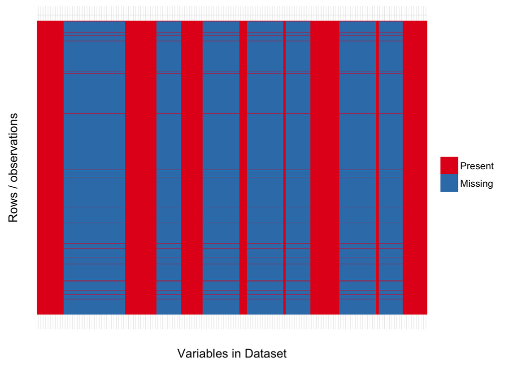

Missingness Map of the WLE dataset

```r
# produces missingness map
ggplot_missing <- function(x){

  x %>%
    is.na %>%
    melt %>%
    ggplot(data = .,
           aes(x = Var2,
               y = Var1)) +
    geom_raster(aes(fill = value)) +
    scale_fill_brewer(name = "",
                    labels = c("Present","Missing"), palette = "Set1") +
    theme_minimal() +
    theme(axis.text.x  = element_blank(),
          axis.ticks.x = element_blank(),
          axis.text.y = element_blank(),
          axis.ticks.y = element_blank()) +
    labs(x = "Variables in Dataset",
         y = "Rows / observations")
}

ggplot_missing(Data)
```

The missingness map shows that the variables that contain missing values have a high missingness rate. Also the missingness according to the missingness map has a pattern to it and is therefore of the type **MNAR** (Missing Not At Random), that is missing systematically, so imputation would not be a good option. Hence, **the variables that contain these missing values would be discarded from the data set**. Also, Variables that serve as identifiers and time stamps would be discarded as they add no information to the analysis.

## General Preprocessing

The dataset is preprocessed accroding to the outline above, in the code below. First, variables that add no information to the analysis (Identifiers and timestamps) are discarded, then the function *missThreshold* deletes all variables That have a threshold equal to, or greater than the threshold argument passed to it.

```r
missThreshold = function(dataframe, threshold){

        set.seed(1)
        # Shuffles Dataframe
        x = dataframe[sample(seq_len(nrow(dataframe)), nrow(dataframe)), ]

        # Computes the percentage missing in each variable
        percentMissing = sapply(x, function(x){
                sum(is.na(x))* 100/length(x)
        } )

        # Determines which variables to keep or discard
        toKeep = ifelse(percentMissing <= threshold, 1, 0)
        toKeep = toKeep == 1
        x[toKeep]
}

# Removes Variables That are included only for identification and have no meaning to the Data
Data = Data[,-(1:7)]

# Removes Variables that have missingness rate of greater than or equal to 80 percent
Data = missThreshold(Data, 80)

Data = transform(Data, classe = factor(classe))

rm(missThreshold)
```

## Model Building & Cross Validation

The model is built using the train function from the caret package. The model is the cross-validated using k-fold cross validation as specified by the *fitControl* Variable.

Two Models are built using the using the **Random Forest** and **CART** algorithms, and the models are cross-validated using the *cv* data subset to select the better. The accuracy of the better model is then evaluated using the *Testing* data subset.

```r
suppressPackageStartupMessages(library(caret))
set.seed(1)
# splits Data into Training and Testing Sets
inTrain = createDataPartition(Data$classe, p = 0.8 , list = F)
Training = Data[inTrain,]
Testing = Data[-inTrain,]

# splits Testing into Cross-Validation and OOS Test
inCv = createDataPartition(Testing$classe, p = 1/3, list = F)
cv = Testing[inCv,]
Testing = Testing[-inCv,]


fitControl = trainControl(method = "cv",
                          number = 5,
                          allowParallel = T)

tuningGrid = expand.grid(cp = seq(.00006,.0004,.00002))


set.seed(1)
# fits a random Forest model
fitRf = train(classe ~., data = Training, method = "rf", trControl = fitControl)

set.seed(1)
# fits a CART model
fitCART =  train(classe ~., data = Training, method = "rpart",
            trControl = fitControl, tuneGrid = tuningGrid)


rm(inTrain, inCv, Data, tuningGrid, fitControl)
```

#### RandomForest Accuracy

```r
confusionMatrix(predict(fitRf, cv), cv$classe)$overall["Accuracy"]
```

```
 Accuracy
0.9915966
```

#### CART Accuracy

```r
confusionMatrix(predict(fitCART, cv), cv$classe)$overall["Accuracy"]
```

```
 Accuracy
0.9396486
```

## Conclusion

The random forest model shows a superior accuracy to the CART model, and is therefore selected.

```r
print(fitRf)
```

```
Random Forest

15699 samples
   52 predictor
    5 classes: 'A', 'B', 'C', 'D', 'E'

No pre-processing
Resampling: Cross-Validated (5 fold)
Summary of sample sizes: 12559, 12558, 12559, 12561, 12559
Resampling results across tuning parameters:

  mtry  Accuracy   Kappa
   2    0.9932479  0.9914586
  27    0.9926108  0.9906523
  52    0.9864326  0.9828372

Accuracy was used to select the optimal model using  the largest value.
The final value used for the model was mtry = 2.
```

## Testing for Out-of-Sample Accuracy

The outcome of the *Testing* dataset is predicted by calling the predict function on the model *fitRf* using the Testing dataset. The predictions are then compared to the actual values of the *classe* variable using a confusion matrix generated by the *confusionMatrix* function.

```r
# Predicts the outcome of the Testing data set
predTest = predict(fitRf, Testing)

# Creates the confusion Matrix which generates the out-of-sample accuracy
confusionMatrix(predTest, Testing$classe)
```

```
Confusion Matrix and Statistics

          Reference
Prediction   A   B   C   D   E
         A 744   2   0   0   0
         B   0 501   3   0   0
         C   0   3 453   2   0
         D   0   0   0 426   3
         E   0   0   0   0 477

Overall Statistics

               Accuracy : 0.995
                 95% CI : (0.9915, 0.9973)
    No Information Rate : 0.2846
    P-Value [Acc > NIR] : < 2.2e-16

                  Kappa : 0.9937
 Mcnemar's Test P-Value : NA

Statistics by Class:

                     Class: A Class: B Class: C Class: D Class: E
Sensitivity            1.0000   0.9901   0.9934   0.9953   0.9938
Specificity            0.9989   0.9986   0.9977   0.9986   1.0000
Pos Pred Value         0.9973   0.9940   0.9891   0.9930   1.0000
Neg Pred Value         1.0000   0.9976   0.9986   0.9991   0.9986
Prevalence             0.2846   0.1936   0.1744   0.1637   0.1836
Detection Rate         0.2846   0.1917   0.1733   0.1630   0.1825
Detection Prevalence   0.2854   0.1928   0.1752   0.1641   0.1825
Balanced Accuracy      0.9995   0.9943   0.9956   0.9970   0.9969
```

```r
rm(Training, Testing, cv, fitCART)
```

## Prediction

```r
pred = predict(fitRf, Submission)
prediction = data.frame(problem.no = 1:20, classe = pred)

prediction
```

```
   problem.no classe
1           1      B
2           2      A
3           3      B
4           4      A
5           5      A
6           6      E
7           7      D
8           8      B
9           9      A
10         10      A
11         11      B
12         12      C
13         13      B
14         14      A
15         15      E
16         16      E
17         17      A
18         18      B
19         19      B
20         20      B
```